# Whats going on in my Instagram?

## Does more instagram notes mean more unseen stories?

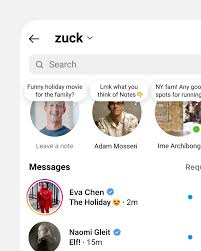

[figure not shown]

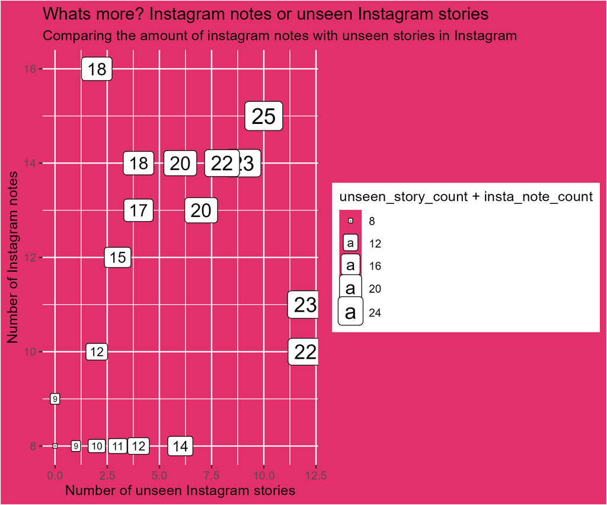

For this plot, I checked if there is a relationship between unseen stories and Instagram notes. The size of the labels is dicatated by the amount of unseen stories plus the amount of Instagram notes I see. From what I see generally, the more stories that I don’t view, the more Instagram notes there will be from my followers.

## How much of the first posts I see are posts?

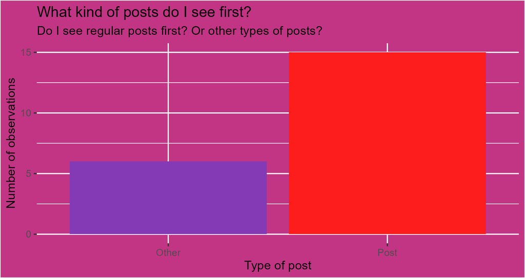

A plot displaying how much more posts I see compared to other types of posts

In this plot, both multi posts and posts are combined into the variable post. The rest of the other types of posts are declared as “other”. This plot observes what kind of posts I see first as soon as I open the app. From the 21 observations, I tend to see more posts first than other types of post, such as reels or ads.

## What kind fo posts do I see in different hours of the day?

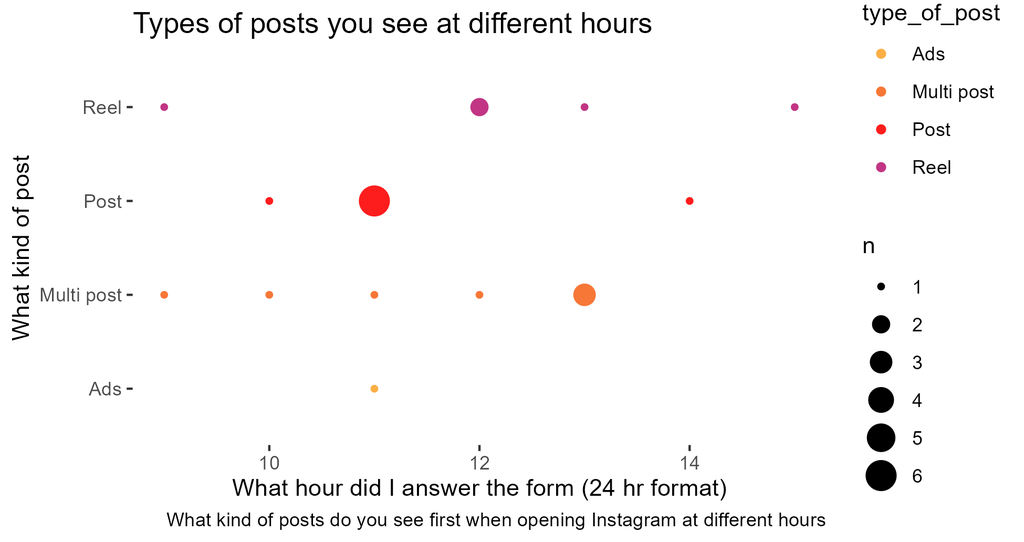

A plot showing the different types of posts I see at a given time at a day

In this plot, I am comparing what kind of posts I tend to see in different hours of the day. The hours is displayed at a 24 hr format. The size of each point dictates how much more I see that type of post in that hour. From what I see, I see single posts the most at 11am as soon as I open the app. Which is followed by multi posts in 1pm and reels at 12pm.